# “p-values” and other “rare animals”

A self-study note on frequentist evidence, likelihood, and Bayesian inference

**NoteHow to use this note**

This note is meant to be read alongside the R output and figures. The main goal is **not** to memorise formulas or critical values. Instead, keep four questions in mind:

1. **What is treated as random?**
2. **What are we conditioning on?**
3. **What question does a p-value actually answer?**
4. **How is that question different from the one answered by a Bayesian posterior?**

The last part introduces Bayesian inference only to make this contrast clear. You will work much more with Bayesian methods in the next class.

## Probabilistic interpretations

What is the probability…

- of getting heads when flipping a coin?
- that I learn something new during this lecture?

These questions both use the word *probability*, but they need not invoke exactly the same interpretation of probability.

For a repeatable experiment such as coin tossing, a frequentist interpretation is natural: probability is linked to what would happen over many repetitions. For a statement about an uncertain event that will occur only once, probability is often used more broadly as a way of expressing uncertainty.

The distinction matters because the classical tools used below—p-values, confidence intervals, and hypothesis tests—are built on a **repeated-sampling** interpretation.

## The frequentist (empirical) interpretation

A simplified frequentist definition is

$$P(x)=\lim_{N\rightarrow\infty}\frac{n_x}{N},$$

where $n_x$ is the number of times event $x$ occurs and $N$ is the total number of repetitions.

The idea is that, in the long run, the relative frequency of an event converges to its probability.

**ImportantKey point**

In frequentist inference, probability statements are attached to **random procedures and repeated samples**. Once a particular parameter value is fixed, the parameter itself is not treated as random.

This is why a classical 95% confidence interval and a p-value are interpreted through hypothetical repetitions of the sampling process.

## The law of large numbers

Consider a simple experiment: toss a fair coin 10,000 times. What happens to the observed proportion of heads as the number of tosses grows?

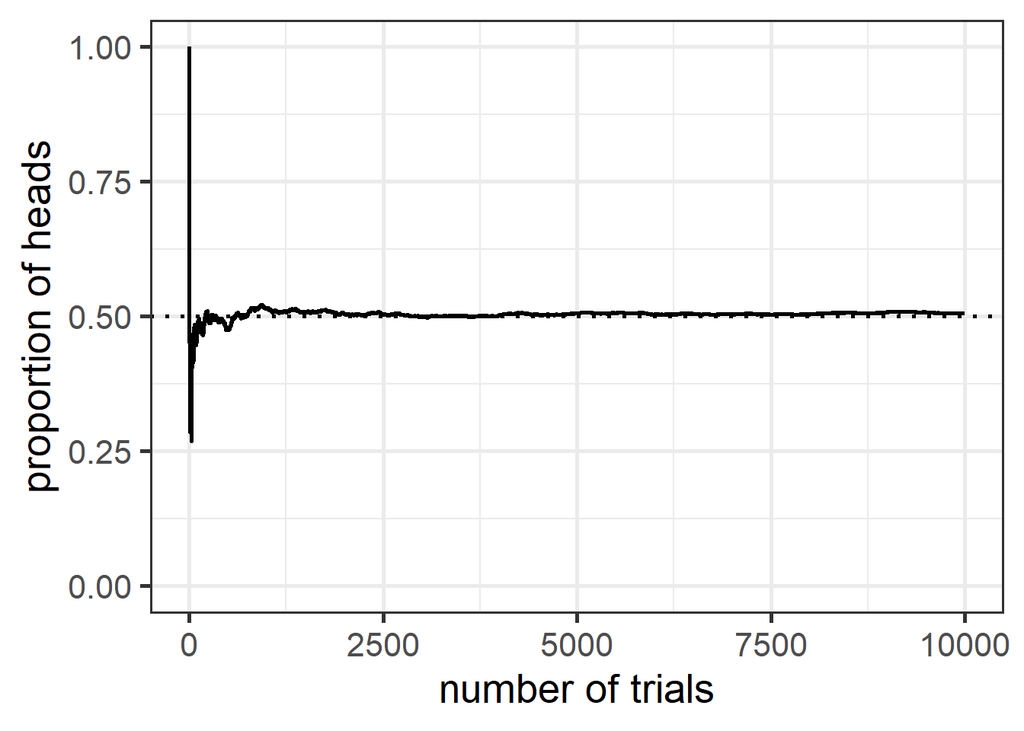

```r
library(tidyverse)

set.seed(3020)

sample(c(0, 1), 10000, replace = TRUE) %>%
  data.frame %>%
  mutate(x = seq_along(.), y = cumsum(.) / seq_along(.)) %>%
  ggplot(aes(x = x, y = y)) +
  geom_line(linewidth = 1) +
  geom_hline(yintercept = 0.5, linetype = 3) +
  xlab("number of trials") +
  ylab("proportion of heads") +
  ylim(0, 1) +
  theme_bw(base_size = 20)
```

At the beginning, the observed proportion can move considerably. As the number of trials increases, it tends to stabilise around 0.5.

This illustrates the **law of large numbers**: under suitable conditions, a sample average converges toward its population expectation as the sample size increases.

**TipConnection to econometrics**

We rarely observe repeated copies of the same economic dataset. Nevertheless, frequentist inference asks us to reason about what our estimator **would have done across hypothetical repeated samples generated by the same process**.

## Null Hypothesis Significance Testing (NHST)

We now create a simple example in which we are interested in height differences between women and men.

For the data-generating process in this example, suppose:

- the population mean for women is 170 cm;
- the population mean for men is 175 cm;
- both population standard deviations are 10 cm;
- we observe 100 people from each population.

```r
sample_size <- 100

set.seed(429)
women <- rnorm(sample_size, mean = 170, sd = 10)

set.seed(231)
men <- rnorm(sample_size, mean = 175, sd = 10)

t.test(
  women,
  men,
  var.equal = TRUE,
  alternative = "two.sided",
  mu = 0,
  conf.level = .95
)
```

```
    Two Sample t-test

data:  women and men
t = -2.8579, df = 198, p-value = 0.004721
alternative hypothesis: true difference in means is not equal to 0
95 percent confidence interval:
 -6.568853 -1.204791
sample estimates:
mean of x mean of y
 170.8268  174.7136
```

The sample means will not be exactly 170 and 175 because the samples are random. The t-test asks whether the **observed difference between the sample means is unusually large relative to the sampling variation we would expect if the population means were actually equal**.

That last sentence is the logic of the test.

## The t-distribution of the null hypothesis

We are testing equality of two population means:

$$H_0:\mu_{women}=\mu_{men},$$

or equivalently

$$H_0:\mu_{women}-\mu_{men}=0.$$

Under the equal-variance assumption, the two-sample t-statistic is

$$t=
\frac{(\bar{x}_1-\bar{x}_2)-(\mu_1-\mu_2)}
{s_p\sqrt{\frac{1}{n_1}+\frac{1}{n_2}}},$$

where

$$s_p=
\sqrt{
\frac{(n_1-1)s_1^2+(n_2-1)s_2^2}
{n_1+n_2-2}
}.$$

Here:

- $\bar{x}_1$ and $\bar{x}_2$ are the two sample means;
- $\mu_1-\mu_2$ is the difference hypothesised under $H_0$;
- $n_1$ and $n_2$ are the sample sizes;
- $s_p$ is the pooled estimate of the common population standard deviation.

For our null hypothesis, the hypothesised difference is zero, so conceptually the test statistic is simply

$$\boxed{
t=\frac{\text{observed difference}-\text{hypothesised difference}}
{\text{standard error of the observed difference}}
}$$

or

$$t=\frac{(\bar{x}_1-\bar{x}_2)-0}
{se(\bar{x}_1-\bar{x}_2)}.$$

**ImportantHow to read a t-statistic**

A t-statistic is a **distance measured in standard-error units**. A value such as $t=0.4$ means that the estimate is close to the null value relative to its sampling uncertainty. A value such as $t=3$ means that the estimate is three standard errors away from the null value.

If $H_0$ is true and the assumptions of the test hold, this statistic follows a t-distribution with $n_1+n_2-2$ degrees of freedom.

## Simulated t-distribution under the null hypothesis

The t-distribution is easier to understand if we simulate the repeated-sampling experiment directly.

We now generate 10,000 datasets **under the null hypothesis**. Both groups are generated with mean 170, so in these simulated populations there is no true difference between women and men.

For each simulated dataset we calculate a t-statistic.

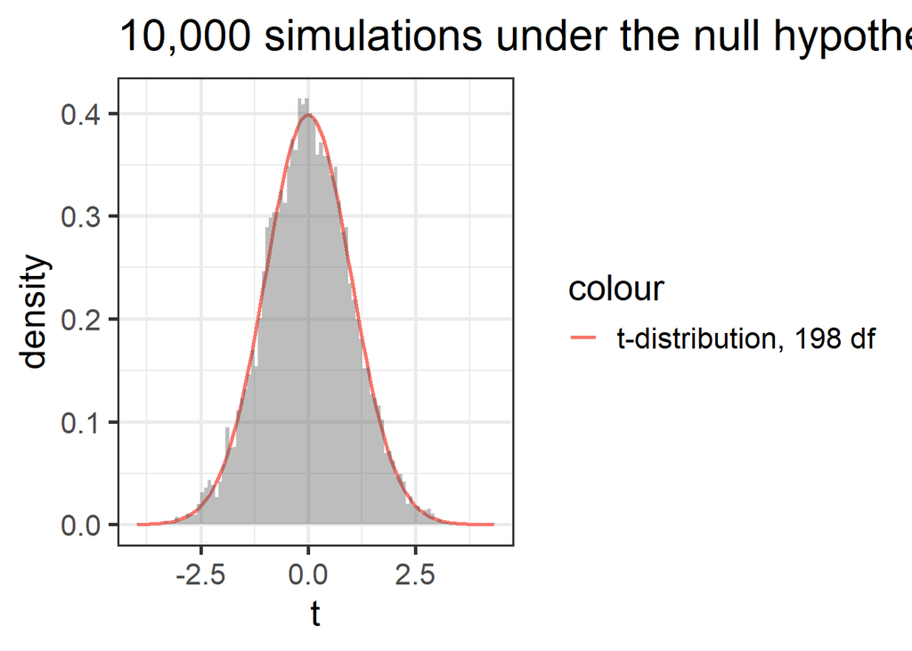

```r
library(mosaic)

nsim <- 10000

df <- t.test(
  women,
  men,
  var.equal = TRUE,
  alternative = "two.sided",
  mu = 0,
  conf.level = .95
)$parameter

t <- do(nsim) *
  t.test(
    rnorm(100, 170, 10),
    rnorm(100, 170, 10),
    var.equal = TRUE
  )$statistic

t %>%
  ggplot(aes(x = t)) +
  stat_function(
    fun = dt,
    args = list(df = df),
    aes(colour = "t-distribution, 198 df")
  ) +
  geom_histogram(aes(y = after_stat(density)), alpha = 0.4, bins = 100) +
  ggtitle("10,000 simulations under the null hypothesis") +
  theme_bw(base_size = 20)
```

Most simulated t-statistics fall near zero because the null hypothesis is true in the simulation. Large positive or negative statistics occur occasionally because random samples can differ even when their population means are identical.

This simulated distribution answers an important question:

> **What values of the test statistic would we see if $H_0$ were true and we repeated the experiment many times?**

That is the reference distribution used to interpret the t-statistic from our actual sample.

## p-values

A p-value is a **tail probability in the sampling distribution of the test statistic under the null hypothesis**.

For a two-sided test,

$$p
=
P_{H_0}\left(|T|\geq |t_{obs}|\right).$$

In words:

> **Assuming $H_0$ is true, what is the probability of obtaining a test statistic at least as extreme as the one we observed?**

This is a conditional probability statement. The condition is important:

$$\boxed{\text{p-value is calculated assuming }H_0\text{ is true}.}$$

### Critical values

At a significance level of $\alpha=0.05$, a two-sided test places 2.5% of the null distribution in each tail.

```r
alpha <- 0.05
abs(qt(alpha / 2, df = df))
```

```
[1] 1.972017
```

We can obtain approximately the same cutoffs from the simulated null distribution:

```r
mosaic::qdata(~t, c(0.025, 0.975), data = t)
```

```
     2.5%     97.5%
-1.990344  2.002079
```

### Our observed t-statistic

```r
obs.t.value <- abs(
  t.test(women, men, var.equal = TRUE)$statistic
)
obs.t.value
```

```
       t
2.857865
```

And the corresponding p-value calculated by `t.test()` is:

```r
t.test(women, men, var.equal = TRUE)$p.value
```

```
[1] 0.004721039
```

We can reproduce the same two-sided tail area by integrating the t-density beyond $|t_{obs}|$ in both tails:

```r
2 * integrate(dt, obs.t.value, Inf, df = df)$value
```

```
[1] 0.004721041
```

**WarningA very common misinterpretation**

The p-value is **not**

$$P(H_0\mid\text{data}).$$

Nor is it simply

$$P(\text{data}\mid H_0).$$

It is the probability, **under $H_0$**, of a test statistic at least as extreme as the observed one. The definition therefore depends on the statistic and on what counts as “more extreme,” which in turn depends on the alternative hypothesis.

This distinction between

$$P(\text{evidence}\mid H_0)$$

and

$$P(H_0\mid\text{evidence})$$

is the main conceptual reason for introducing Bayes’ theorem later in this note.

## Plot of the t-test

The following plot shows the t-test using the theoretical distribution that applies when $H_0$ is true.

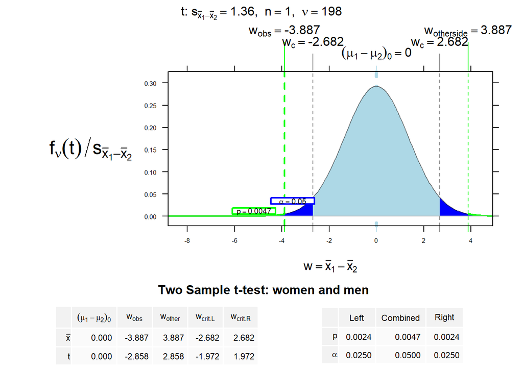

```r
library(HH)
NTplot(
  t.test(
    women,
    men,
    var.equal = TRUE,
    alternative = "two.sided",
    mu = 0,
    conf.level = .95
  )
)
```

Read the graph from the centre outward:

- zero represents the difference predicted by $H_0$;
- the null distribution shows the sampling variation expected around zero;
- the observed t-statistic shows where our sample landed;
- the tail area beyond the observed statistic gives the p-value for the specified test.

## What the null hypothesis and the p-value do—and do not—tell us

A classical significance test proceeds by **temporarily assuming the null hypothesis** and asking whether the observed statistic is unusually far into the tail of the resulting sampling distribution.

This gives a useful diagnostic of compatibility between the observed data and $H_0$.

However, a p-value does **not** directly provide:

- the probability that $H_0$ is true;
- the probability that an alternative hypothesis is true;
- the probability that the estimated effect is “real”;
- the economic or practical importance of the effect.

The alternative hypothesis still matters in frequentist testing because it determines whether we examine a left tail, a right tail, or both tails. But the p-value itself is calibrated using the distribution of the statistic **under $H_0$**. It does not place posterior probabilities on competing hypotheses.

**NoteWhy this matters**

If your scientific question is “How probable is a parameter value after observing the data?”, a classical p-value is not designed to answer that question. Bayesian inference changes the conditioning and asks directly about uncertainty in the parameter **given the observed data and a specified model/prior**.

## Interpreting confidence intervals

A confidence interval uses the same repeated-sampling logic.

A 95% confidence interval does **not** mean that, after observing this particular interval, there is a 95% frequentist probability that the fixed population parameter lies inside it.

Instead, 95% refers to the **procedure**:

> If we repeatedly drew samples in the same way and constructed an interval from each sample using this procedure, about 95% of those intervals would contain the true population parameter.

Once our particular sample has been observed, the resulting interval either contains the fixed parameter or it does not.

### Confidence intervals and significance tests

For a two-sided test, there is a useful duality:

- a hypothesised parameter value **outside** the 95% confidence interval is rejected by the corresponding two-sided test at $\alpha=0.05$;
- a value **inside** the interval is not rejected by that test.

This does **not** make a confidence interval merely a “significance region.” The interval also communicates a range of parameter values compatible with the data at the chosen confidence level and therefore helps us think about **effect magnitude and precision**, not only a binary reject/do-not-reject decision.

## What have we learned so far?

Frequentist statistics such as p-values and confidence intervals are naturally interpreted using repeated sampling.

The main ideas are:

- the t-statistic measures the distance between an estimate and a hypothesised value in standard-error units;
- its reference distribution is derived under $H_0$;
- the p-value is a tail area in that null distribution;
- the p-value is **not** the probability that the null hypothesis is true;
- confidence levels describe the long-run performance of an interval-producing procedure;
- statistical significance is not the same as economic importance.

The next question is therefore natural:

> **What if we really want a probability statement about an unknown parameter after seeing the data?**

Before answering that, we need one more piece of frequentist logic: the significance level.

## Level of significance and false positives

A **Type I error** occurs when we reject $H_0$ even though $H_0$ is true.

If the test has significance level $\alpha$, then—under the assumptions used to construct the test—

$$P(\text{Type I error}\mid H_0\text{ true})=\alpha.$$

Thus a test with

$$\alpha=0.05$$

is deliberately designed so that, if we repeatedly applied the procedure in situations where the null hypothesis was true, about 5% of those tests would nevertheless reject it.

This is the price of having a rule that can detect departures from $H_0$ using noisy samples.

## Level of significance and the p-value

The usual decision rule is

$$p\leq\alpha
\quad\Rightarrow\quad
\text{reject }H_0.$$

For a fixed test and observed dataset, the p-value can also be described as the **smallest significance level $\alpha$ at which that test would reject $H_0$**.

**WarningDo not turn this into ‘p = probability of a false positive’**

The observed p-value is not the probability that *this particular rejection* is a Type I error. The Type I error rate $\alpha$ is a long-run property of the testing rule under a true null hypothesis.

Notice the asymmetry:

- frequentist testing controls how often a rule rejects when $H_0$ is true;
- it does not assign a probability to $H_0$ after we have observed the data.

That difference in conditioning leads us to Bayes’ theorem.

## From likelihood to posterior probability

Suppose our scientific question concerns an unknown parameter or hypothesis $\theta$.

The **likelihood** asks:

$$p(x\mid\theta),$$

that is:

> If $\theta$ had a particular value, how compatible would the observed data $x$ be with that value?

Once the data are observed, the likelihood can be regarded as a function of $\theta$. Importantly, the likelihood by itself is **not** a probability distribution over $\theta$.

Bayesian inference combines the likelihood with a prior distribution:

$$p(\theta\mid x)
\propto
p(x\mid\theta)p(\theta).$$

Bayes’ theorem gives the normalised posterior:

$$p(\theta\mid x)
=
\frac{p(x\mid\theta)p(\theta)}{p(x)},$$

where

$$p(x)=\int p(x\mid\theta)p(\theta)\,d\theta.$$

**ImportantThe conditioning has changed**

The likelihood is about

$$p(\text{data}\mid\theta),$$

whereas the Bayesian posterior is about

$$p(\theta\mid\text{data}).$$

These are **not the same quantity**. Bayes’ theorem tells us how to move from one to the other by combining the likelihood with prior information and normalising.

This is the central reason Bayesian inference appears in this note. The goal here is not to teach Bayesian computation in detail, but to make the distinction between **likelihood-based evidence** and **posterior uncertainty** explicit.

## Bayes’ theorem

For continuous parameters we usually work with densities:

- $p(\theta\mid x)$: posterior density of $\theta$ given the observed data $x$;
- $\theta$: a parameter or vector of parameters;
- $x$: the observed data;
- $p(x\mid\theta)$: sampling model; viewed as a function of $\theta$ after observing $x$, it is the likelihood;
- $p(\theta)$: prior density for $\theta$;
- $p(x)$: marginal likelihood, which normalises the posterior so its total probability is one.

Thus,

$$\boxed{
p(\theta\mid x)
=
\frac{p(x\mid\theta)p(\theta)}
{\int p(x\mid\theta)p(\theta)\,d\theta}
}$$

or, when we only need the posterior up to proportionality,

$$p(\theta\mid x)\propto p(x\mid\theta)p(\theta).$$

## Bayesian inference

A useful three-step description, following Gelman *et al.* (2013), is:

1. **Build the model:** specify how the data are generated (the likelihood) and express prior information or assumptions through priors.
2. **Update with the data:** use Bayes’ theorem to obtain or approximate the posterior distribution.
3. **Evaluate and interpret:** check the model, examine its fit and assumptions, summarise posterior quantities, and revise the model when necessary.

A useful intuition from McElreath (2015) is that Bayesian inference considers the range of possibilities that could have produced what we observed and then updates their relative plausibility in light of the data.

**NoteFor this course**

This is only a bridge. You will study Bayesian inference in more depth in the next class. Here, concentrate on the conceptual contrast:

$$\text{frequentist test: }p(\text{test statistic as/extreme}\mid H_0)$$

versus

$$\text{Bayesian inference: }p(\theta\mid\text{data, model, prior}).$$

## The t-test as a linear model

The difference-in-means problem can also be written as a regression:

$$height_i=\beta_1+\beta_2 gender_i+u_i.$$

In the code below, `gender = 0` for men and `gender = 1` for women. Therefore:

$$\beta_1=E(height\mid gender=0),$$

which is the mean height for men, and

$$\beta_2
=
E(height\mid gender=1)-E(height\mid gender=0),$$

which is the **women-minus-men mean difference**.

Testing equality of the two population means is therefore equivalent to testing

$$H_0:\beta_2=0.$$

```r
women <- tibble(height = women)
women <- women %>% mutate(gender = 1)

men <- tibble(height = men)
men <- men %>% mutate(gender = 0)

dframe <- dplyr::bind_rows(women, men)

summary(lm(height ~ gender, data = dframe))
```

```
Call:
lm(formula = height ~ gender, data = dframe)

Residuals:
     Min       1Q   Median       3Q      Max
-23.4549  -7.1704   0.3472   6.0785  26.8372

Coefficients:
            Estimate Std. Error t value Pr(>|t|)
(Intercept) 174.7136     0.9617 181.672  < 2e-16 ***
gender       -3.8868     1.3600  -2.858  0.00472 **
---
Signif. codes:  0 '***' 0.001 '**' 0.01 '*' 0.05 '.' 0.1 ' ' 1

Residual standard error: 9.617 on 198 degrees of freedom
Multiple R-squared:  0.03962,   Adjusted R-squared:  0.03476
F-statistic: 8.167 on 1 and 198 DF,  p-value: 0.004721
```

The coefficient on `gender` should reproduce the sample difference in group means. With the usual homoskedastic standard error, the corresponding regression t-test is the same inferential problem as the equal-variance two-sample t-test.

```r
diffmean(height ~ gender, data = dframe)
```

```
 diffmean
-3.886822
```

**TipWhy this matters for econometrics**

A two-sample t-test is not a separate statistical universe. It is a very simple regression model with a binary explanatory variable. Soon, the same logic will be used for regression coefficients with several explanatory variables.

## The t-test as a Bayesian linear model (1): model and prior

We can use the **same regression equation** in a Bayesian model:

$$height_i\sim N(\mu_i,\sigma),$$

with

$$\mu_i=\beta_1+\beta_2 gender_i.$$

The likelihood describes the distribution of heights conditional on the parameters. The Bayesian model adds prior distributions for those parameters and then uses the observed heights to obtain a posterior distribution.

```r
library(brms)

prior <- get_prior(height ~ gender, data = dframe)
prior
```

```
                   prior     class   coef group resp dpar nlpar lb ub
                  (flat)         b
                  (flat)         b gender
 student_t(3, 172.4, 10) Intercept
     student_t(3, 0, 10)     sigma                               0
       source
      default
 (vectorized)
      default
      default
```

The next step gives the `gender` coefficient a normal prior centred on zero with standard deviation 10 cm:

```r
prior$prior[2] <- "normal(0, 10)"
prior
```

```
                   prior     class   coef group resp dpar nlpar lb ub  source
                  (flat)         b                                    default
           normal(0, 10)         b gender                             default
 student_t(3, 172.4, 10) Intercept                                    default
     student_t(3, 0, 10)     sigma                               0    default
```

This prior says that, before using the current data, differences reasonably close to zero are more plausible than extremely large differences, while still allowing substantial positive or negative differences.

### Why the Bayesian sampling is not run here

Bayesian estimation with `brms` uses MCMC sampling and can take time. For this self-study note, the model has therefore been estimated beforehand and the fitted object is loaded into the R session.

**This is intentional.** The purpose of this section is to compare the *interpretation* of frequentist and Bayesian inference, not to teach MCMC computation. You will return to Bayesian computation in the next class.

```r
setwd("C:/Users/omy000/OneDrive - UiT Office 365/Hdisk/omy000 (homer.uit.no)/poe5/h2026")

# The model was estimated beforehand with:
# fit.brms <- brm(height ~ gender, data = dframe, prior = prior)
# save(fit.brms, file = "fitbrms")

load("fitbrms")
summary(fit.brms)
```

```
 Family: gaussian
  Links: mu = identity; sigma = identity
Formula: height ~ gender
   Data: dframe (Number of observations: 200)
  Draws: 4 chains, each with iter = 2000; warmup = 1000; thin = 1;
         total post-warmup draws = 4000

Regression Coefficients:
          Estimate Est.Error l-95% CI u-95% CI Rhat Bulk_ESS Tail_ESS
Intercept   174.66      0.94   172.85   176.51 1.00     4259     3109
gender       -3.80      1.34    -6.45    -1.17 1.00     4191     3084

Further Distributional Parameters:
      Estimate Est.Error l-95% CI u-95% CI Rhat Bulk_ESS Tail_ESS
sigma     9.66      0.49     8.76    10.65 1.00     4068     2896

Draws were sampled using sampling(NUTS). For each parameter, Bulk_ESS
and Tail_ESS are effective sample size measures, and Rhat is the potential
scale reduction factor on split chains (at convergence, Rhat = 1).
```

When reading the summary, focus especially on the posterior distribution of the `gender` coefficient $\beta_2$. Remember that, with our coding, a negative value means that women are shorter on average than men in this model.

## The t-test as a Bayesian linear model (2): posterior distributions

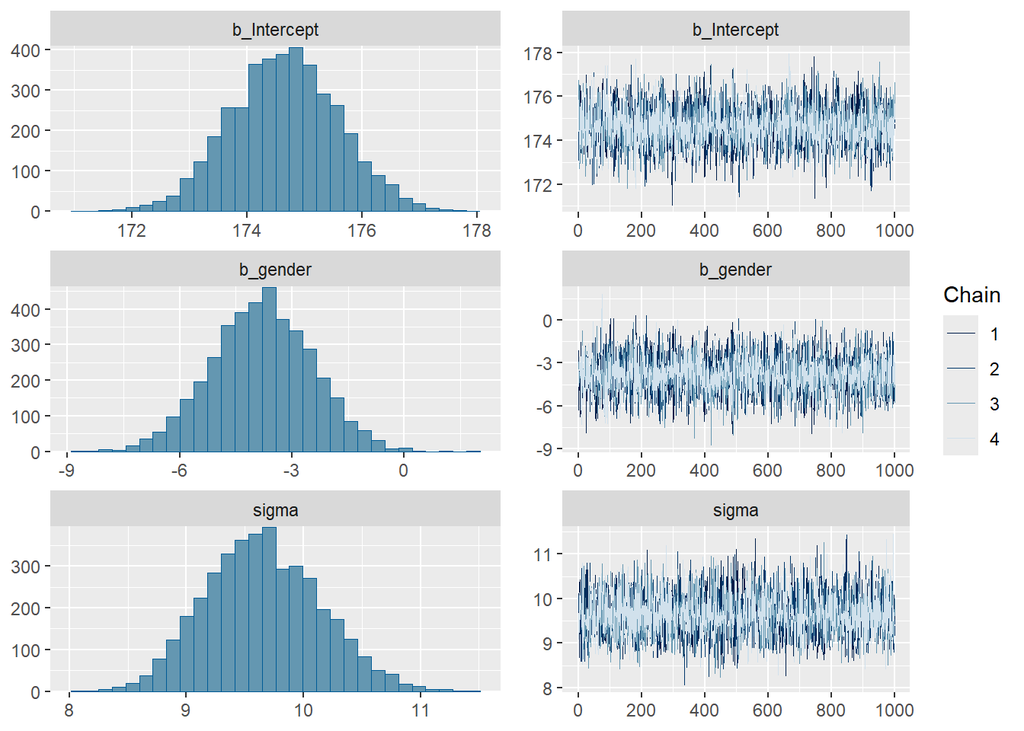

```r
plot(fit.brms)
```

These plots summarise the posterior distributions and the MCMC sampling behaviour.

For the present purpose, the important conceptual point is that we now have a **distribution describing uncertainty about the model parameters conditional on the observed data and the chosen prior/model**.

That allows probability statements about parameter regions that are not p-value statements.

For example, we can ask whether the posterior puts most of its mass below zero, above zero, or across both sides of zero.

## The t-test as a Bayesian linear model (3): a hypothesis about the coefficient

The frequentist null hypothesis was

$$H_0:\beta_2=0.$$

We can examine the analogous contrast in the fitted Bayesian model:

```r
hyptest0 <- hypothesis(fit.brms, "gender=0")
hyptest0
```

```
Hypothesis Tests for class b:
    Hypothesis Estimate Est.Error CI.Lower CI.Upper Evid.Ratio Post.Prob Star
1 (gender) = 0     -3.8      1.34    -6.45    -1.17         NA        NA    *
---
'CI': 90%-CI for one-sided and 95%-CI for two-sided hypotheses.
'*': For one-sided hypotheses, the posterior probability exceeds 95%;
for two-sided hypotheses, the value tested against lies outside the 95%-CI.
Posterior probabilities of point hypotheses assume equal prior probabilities.
```

Be careful with interpretation here. With continuous parameter distributions, the posterior probability of the single point $\beta_2=0$ is not interpreted in the same simple way as the probability of an interval or direction such as $\beta_2<0$.

The `hypothesis()` function reports Bayesian summaries of the specified contrast; depending on the priors and hypothesis, these may include posterior estimates and evidence ratios. These are **not p-values** and should not be read using frequentist significance rules.

## The t-test as a Bayesian linear model (4): visualising the contrast

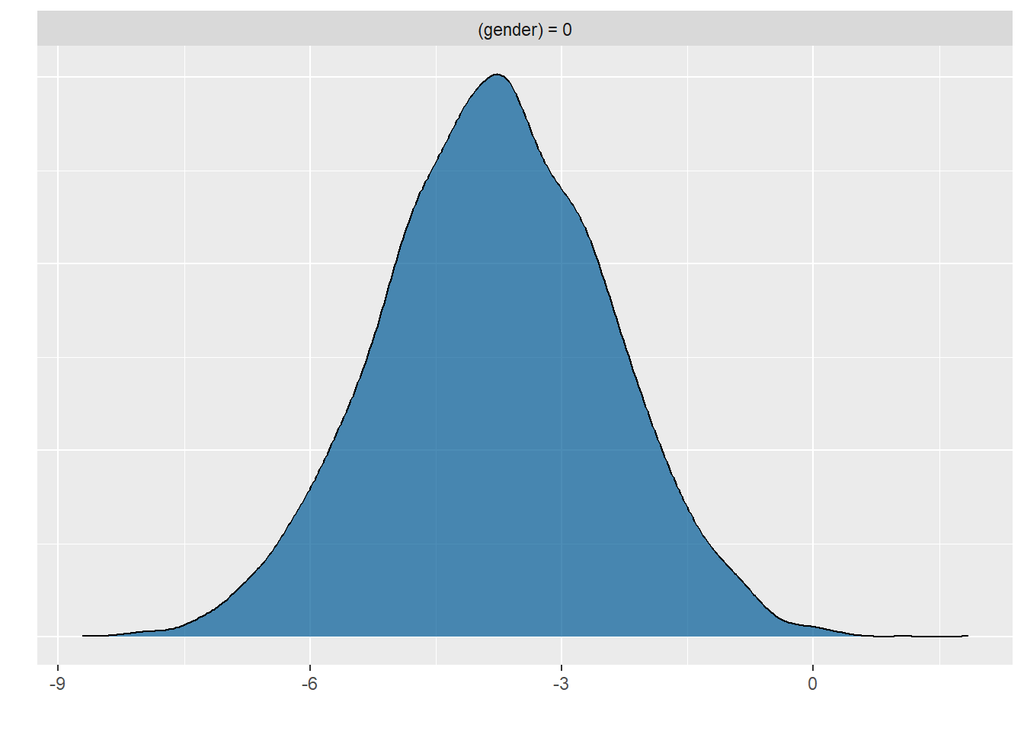

```r
plot(hyptest0)
```

The plot makes the posterior uncertainty about the contrast visible.

Compare this mentally with the earlier t-distribution plot:

- the t-distribution was a distribution of a **test statistic over hypothetical repeated samples under $H_0$**;
- this plot is based on uncertainty about a **parameter/contrast after conditioning on the data and prior/model**.

Those are different probability objects.

Finally, the posterior draws let us ask a direct directional probability question:

```r
prop(hyptest0$samples >= 0)
```

```
prop_TRUE
  0.00225
```

This estimates the posterior proportion of draws for the contrast that are at least zero.

With our coding (`gender = 1` for women, `gender = 0` for men), the economically relevant sign should be interpreted accordingly.

**ImportantFinal comparison**

Do not compare a p-value of, say, 0.01 with a Bayesian posterior probability of 0.99 as though they were complements of one another. They condition on different things and answer different questions.

**Frequentist p-value**

$$P_{H_0}(|T|\ge |t_{obs}|)$$

asks how unusual the observed test statistic would be in repeated samples if the null hypothesis were true.

**Bayesian posterior**

$$p(\theta\mid x)$$

describes uncertainty about the parameter after combining the likelihood from the observed data with the prior.

Understanding that reversal of conditioning is the main learning objective of this note.

## A short self-check

Before moving on, make sure you can answer these questions without looking back:

1. What is random in the repeated-sampling interpretation of a p-value?
2. Why is a p-value not $P(H_0\mid\text{data})$?
3. What does $\alpha=0.05$ control in repeated applications of a test?
4. Why can a 95% confidence interval not be interpreted as a 95% frequentist probability statement about the particular realised interval?
5. What is the difference between a likelihood $p(x\mid\theta)$ and a posterior $p(\theta\mid x)$?
6. In the regression `height ~ gender`, what does the coefficient on `gender` represent with the coding used here?
7. Why is the precomputed `brms` object loaded rather than estimated during this document?

If these seven answers are clear, you have the conceptual foundation needed for both classical regression inference and the Bayesian material that follows in the next class.